# STAT 448 Final Project by Yifei Kang

## The Public Use Natality File Data Analysis

### Created by Yifei Kang (yifeik3)

Import the 2015 US Natality Data using an R code chunk and the data URL https://uofi.box.com/shared/static/2dj9jcv0cwrz2l5d5ubu2msje0bqt5wo.csv.

The dataset (.csv) contains 200000 observations and 22 columns and represents less than 5% of the entire data available. The observations are registered births in the United States for year 2015 with various measures about the mother, the child(ren) she birthed, and their health outcomes including pre- and post-partum care. Specifically, the columns are MAGER, FAGECOMB, MEDUC, MRACEHISP, ILP_R, PRECARE, PREVIS, WIC, CIG_0, CIG_1, CIG_2, CIG_3, M_HT_IN, BMI, PWGT_R, DWGT_R, WTGAIN, APGAR5, DPLURAL, SEX, DBWT, and BFED. The original source is the National Vital Statistics System (NVSS), a component of the Center for Disease Control and Prevention’s (CDC) National Center for Health Statistics (NCHS) https://www.cdc.gov/nchs/nvss/births.htm. The data [User Guide](https://uofi.box.com/shared/static/ub0tgcz91z2fpnoc1yazkss5yt2bobhy.pdf) is quite helpful for understanding the variables and their values.

Now, print the descriptor portion of the data.

```r
library(tidyverse)
library(agricolae)
data <- read_csv("https://uofi.box.com/shared/static/2dj9jcv0cwrz2l5d5ubu2msje0bqt5wo.csv")
str(data)
```

```
## tibble [200,000 × 22] (S3: spec_tbl_df/tbl_df/tbl/data.frame)
##  $ MAGER    : num [1:200000] 23 36 19 25 28 23 23 33 30 29 ...
##  $ FAGECOMB : num [1:200000] 26 42 19 28 31 24 25 34 62 31 ...
##  $ MEDUC    : num [1:200000] 2 7 4 3 6 3 2 6 3 6 ...
##  $ MRACEHISP: num [1:200000] 4 1 1 4 1 4 1 1 4 6 ...
##  $ ILP_R    : num [1:200000] 12 999 888 92 888 999 58 888 66 888 ...
##  $ PRECARE  : num [1:200000] 4 2 7 2 2 4 7 3 4 2 ...
##  $ PREVIS   : num [1:200000] 5 15 7 9 13 7 15 9 12 10 ...
##  $ WIC      : chr [1:200000] "Y" "N" "Y" "N" ...
##  $ CIG_0    : num [1:200000] 0 0 0 0 0 0 0 0 0 0 ...
##  $ CIG_1    : num [1:200000] 0 0 0 0 0 0 0 0 0 0 ...
##  $ CIG_2    : num [1:200000] 0 0 0 0 0 0 0 0 0 0 ...
##  $ CIG_3    : num [1:200000] 0 0 0 0 0 0 0 0 0 0 ...
##  $ M_HT_IN  : num [1:200000] 57 66 67 60 69 59 61 62 60 63 ...
##  $ BMI      : num [1:200000] 27.9 30.2 99.9 23.8 33.7 19.8 30.2 29.3 21.5 29 ...
##  $ PWGT_R   : num [1:200000] 129 187 999 122 228 98 160 160 110 164 ...
##  $ DWGT_R   : num [1:200000] 129 190 216 168 228 119 179 178 119 182 ...
##  $ WTGAIN   : num [1:200000] 0 3 99 46 0 21 19 18 9 18 ...
##  $ APGAR5   : num [1:200000] 9 9 9 9 9 9 9 9 9 9 ...
##  $ DPLURAL  : num [1:200000] 1 1 1 1 1 1 1 1 1 1 ...
##  $ SEX      : chr [1:200000] "F" "M" "F" "F" ...
##  $ DBWT     : num [1:200000] 3005 3501 3100 3115 3810 ...
##  $ BFED     : chr [1:200000] "N" "Y" "N" "Y" ...
##  - attr(*, "spec")=
##   .. cols(
##   ..   MAGER = col_double(),
##   ..   FAGECOMB = col_double(),
##   ..   MEDUC = col_double(),
##   ..   MRACEHISP = col_double(),
##   ..   ILP_R = col_double(),
##   ..   PRECARE = col_double(),
##   ..   PREVIS = col_double(),
##   ..   WIC = col_character(),
##   ..   CIG_0 = col_double(),
##   ..   CIG_1 = col_double(),
##   ..   CIG_2 = col_double(),
##   ..   CIG_3 = col_double(),
##   ..   M_HT_IN = col_double(),
##   ..   BMI = col_double(),
##   ..   PWGT_R = col_double(),
##   ..   DWGT_R = col_double(),
##   ..   WTGAIN = col_double(),
##   ..   APGAR5 = col_double(),
##   ..   DPLURAL = col_double(),
##   ..   SEX = col_character(),
##   ..   DBWT = col_double(),
##   ..   BFED = col_character()
##   .. )
```

**#1. Problem** *Is there a gender preference of baby in each race? What is the percentage of each gender in different mother races*

**#1. Plan** *Count the number of newborns of each gender within race, calculate and compare the percentage of genders*

**#1. Data** and **Analysis** *Select column of mother race (MRACEHISP), and gender of the infant (SEX), then draw graph of each gender percentage in each mother race*

```r
data_1 <- data %>%
  select(MRACEHISP, SEX) %>%
  mutate(Race=recode(MRACEHISP,"1" = "White", "2" = "Black", "3" = "AIAN", "4" = "Asian", "5" = "NHOPI", "6" = "More than one race", "7" = "Hispanic", "8" = "Origin unknown or not stated")) %>%
  group_by(Race,SEX) %>%
  summarise(frequencies=n()) %>%
  drop_na() %>%
  mutate(percents = round(frequencies/sum(frequencies),3))
data_1
```

```
## # A tibble: 16 x 4
## # Groups:   Race [8]
##    Race                         SEX   frequencies percents
##    <chr>                        <chr>       <int>    <dbl>
##  1 AIAN                         F            3468    0.493
##  2 AIAN                         M            3564    0.507
##  3 Asian                        F            3118    0.489
##  4 Asian                        M            3252    0.511
##  5 Black                        F           14279    0.495
##  6 Black                        M           14585    0.505
##  7 Hispanic                     F           23733    0.49
##  8 Hispanic                     M           24709    0.51
##  9 More than one race           F            1958    0.489
## 10 More than one race           M            2049    0.511
## 11 NHOPI                        F             494    0.516
## 12 NHOPI                        M             464    0.484
## 13 Origin unknown or not stated F             447    0.478
## 14 Origin unknown or not stated M             489    0.522
## 15 White                        F           50281    0.486
## 16 White                        M           53110    0.514
```

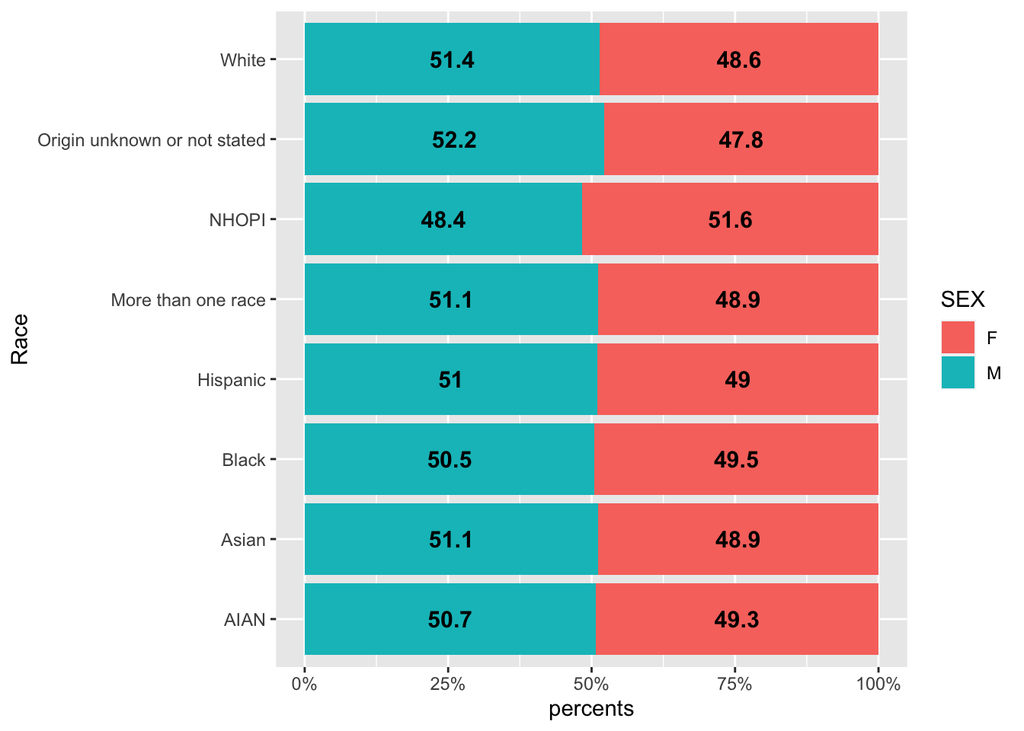

```r
ggplot(data = data_1, aes(x = Race, y = percents, fill = SEX, label = percents*100)) +
  geom_col() +
  geom_text(size = 4, position = position_stack(vjust = 0.5), fontface = "bold")+
  coord_flip() +
  scale_y_continuous(labels = scales::percent)
```

**#1. Conclusion** *Although the number of female and male newborns differs among races, the percentages of female and male are about the same, with overall 49% female and 51% male. The only exception is NHOPI (Native Hawaiian or Other Pacific Islander), which has 51.6% of female and 48.4% of male*

**#2. Problem** *Which race has the highest percentage of mother that has been educated for bachelor’s degree or higher? Which race has the lowest percentage?*

**#2. Plan** *Count and compare the ratio of mother education degree (MEDUC) among different races.*

**#2. Data** and **Analysis** *Assign the respective level of race its actual names. Assign degree levels of MEDUC with level 6, 7, and 8 with “Bachelor’s degree or higher”, and the rest of the degrees with “Other”. Count the number of the two levels, and calculate the percentage within each race. Draw the bar graph according to the percentage levels*

```r
data_2 <- data %>%
  select(MEDUC,MRACEHISP) %>%
  mutate(Race=recode(MRACEHISP, "1" = "White", "2" = "Black", "3" = "AIAN", "4" = "Asian", "5" = "NHOPI", "6" = "More than one race", "7" = "Hispanic", "8" = "Origin unknown or not stated"), Edu=recode(MEDUC,"6"="Bachelor’s degree or higher","7" = "Bachelor’s degree or higher", "8" = "Bachelor’s degree or higher", "1" = "Other", "2" = "Other", "3" = "Other", "4" = "Other", "5" = "Other", "9" = "Other")) %>%
  group_by(Race,Edu) %>%
  summarise(frequencies=n()) %>%
  drop_na() %>%
  mutate(percents = round(frequencies/sum(frequencies),4))
data_2
```

```
## # A tibble: 16 x 4
## # Groups:   Race [8]
##    Race                         Edu                         frequencies percents
##    <chr>                        <chr>                             <int>    <dbl>
##  1 AIAN                         Bachelor’s degree or higher         369   0.0525
##  2 AIAN                         Other                              6663   0.948
##  3 Asian                        Bachelor’s degree or higher        3710   0.582
##  4 Asian                        Other                              2660   0.418
##  5 Black                        Bachelor’s degree or higher        3595   0.124
##  6 Black                        Other                             25269   0.876
##  7 Hispanic                     Bachelor’s degree or higher        5081   0.105
##  8 Hispanic                     Other                             43361   0.895
##  9 More than one race           Bachelor’s degree or higher         806   0.201
## 10 More than one race           Other                              3201   0.799
## 11 NHOPI                        Bachelor’s degree or higher          58   0.0605
## 12 NHOPI                        Other                               900   0.940
## 13 Origin unknown or not stated Bachelor’s degree or higher         164   0.175
## 14 Origin unknown or not stated Other                               772   0.825
## 15 White                        Bachelor’s degree or higher       32569   0.315
## 16 White                        Other                             70822   0.685
```

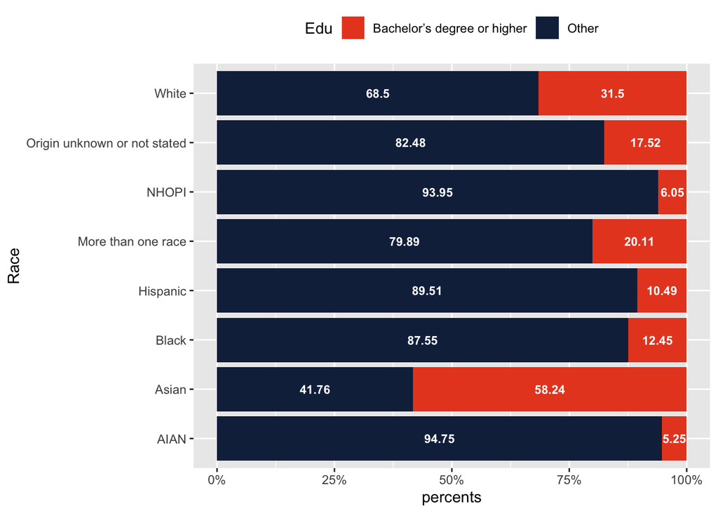

```r
ggplot(data_2, aes(x = Race, y = percents,fill = Edu, label = percents*100)) +
  geom_bar(stat="identity") +
  geom_text(size = 3, position = position_stack(vjust = 0.5), color="white",fontface = "bold")+
  coord_flip()+
  scale_fill_manual(breaks = c("Bachelor’s degree or higher", "Other"), values=c(rgb(232/255,74/255,39/255), rgb(19/255,41/255,75/255)))+
  theme(legend.position = "top")+
  scale_y_continuous(labels = scales::percent)
```

**#2. Conclusion** *The mother degree of education in Asian has the highest percentage of Bachelor’s degree or higher, which is 58.24%. And the education level of AIAN (American Indian or Alaskan Native) has the lowest percentage of Bachelor’s degree or higher, with only 5.25%*

**#3. Problem** *Does the education level of mother affect the birth weight of the baby?*

**#3. Plan** *Compare with birth weight of the baby with different educational level of the mother*

**#3. Data** and **Analysis** *Remove invalid data with birth weight (DBWT) value of 9999. Assign the respective level of MEDUC its actual names. Draw graph of average DBWT for visualization, run LSD comparison by the educational level of mothers*

```r
data_3 <- data %>%
  select(MEDUC, DBWT) %>%
  filter(DBWT<9999)%>%
  mutate(Edu=recode(MEDUC,"1" = "8th grade or less", "2" = "9th through 12th grade with no diploma", "3" = "High school graduate or GED completed", "4" = "Some college credit, but not a degree", "5" = "Associate degree","6"="Bachelor’s degree","7" = "Master’s degree", "8" = "Doctorate or Professional Degree", "9" = "Unknown")) %>%
  group_by(Edu)

Table_3 <- summarise(data_3, Weight=mean(DBWT))
Table_3
```

```
## # A tibble: 9 x 2
##   Edu                                    Weight
##   <chr>                                   <dbl>
## 1 8th grade or less                       3246.
## 2 9th through 12th grade with no diploma  3180.
## 3 Associate degree                        3297.
## 4 Bachelor’s degree                       3343.
## 5 Doctorate or Professional Degree        3308.
## 6 High school graduate or GED completed   3218.
## 7 Master’s degree                         3331.
## 8 Some college credit, but not a degree   3272.
## 9 Unknown                                 3229.
```

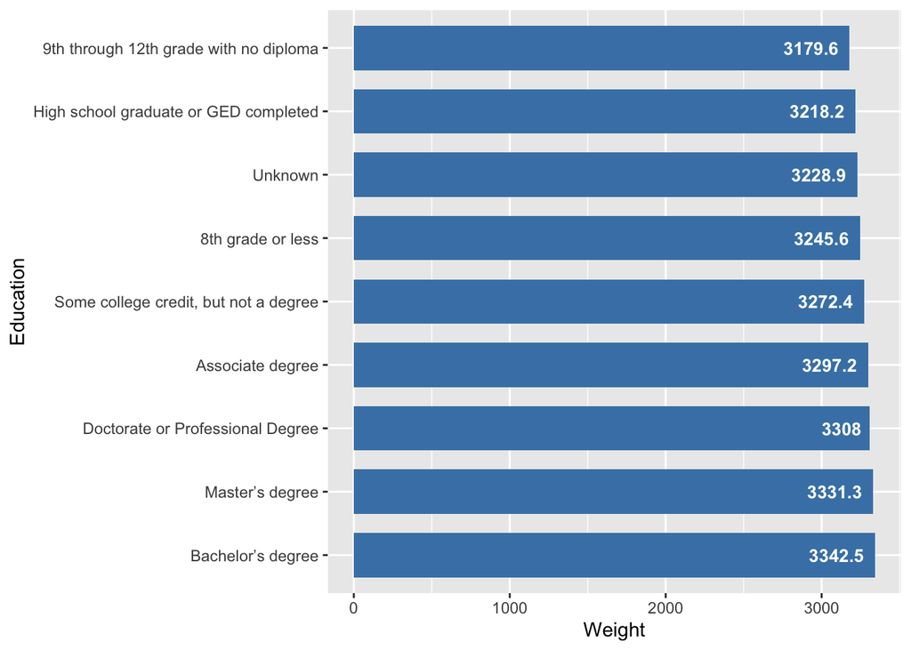

```r
Table_3 %>%
  mutate(Education = fct_reorder(Edu, desc(Weight))) %>%
  ggplot(aes(x=Education, y=Weight)) +
  coord_flip() +
  geom_bar(stat = "identity", width=0.7, fill="steelblue") +
  geom_text(aes(label=round(Weight, digits=1)), color="white", size=3.5,hjust=1.2, fontface = "bold")
```

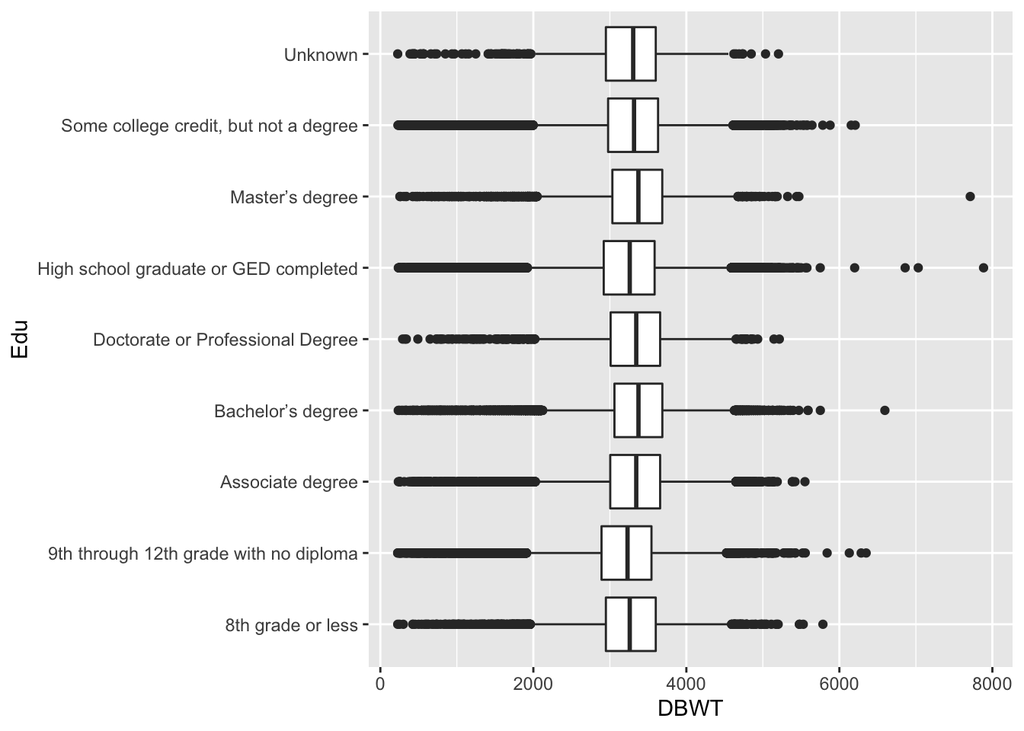

```r
ggplot(data = data_3, aes(x=Edu, y=DBWT)) +
  coord_flip() +
  geom_boxplot()
```

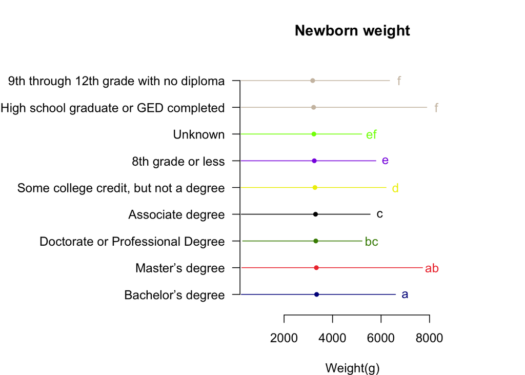

```r
lm <- lm(DBWT~Edu, data=data_3)
out <- LSD.test (lm, "Edu" ,p.adj="bonferroni")
par(mar=c(4,16,4,4))
plot(out, main = "Newborn weight", xlab="Weight(g)",las=1,horiz=T)
```

**#3. Conclusion** *There are significant differences on birth weight among difference educational level of mothers. The average birth weight is highest in mother with bachelor’s degree, which is 3342.5g. The lowest average birth weight is in mother with 9th through 12th grade with no diploma, which is 3179.6g. Overall, the birth weight of baby is higher in mother with bachelor’s degree or higher*

**#4. Problem** *Suppose we want to model baby birth weight in gram (DBWT) using MEDUC, MAGER, PREVIS, BMI, WTGAIN as predictors in a linear regression with model selection. How well does the final model fit?*

**#4. Plan** *Use DBWT as response variable. Proceed with the linear regression modeling strategy (employing the model selection approaches). Create a table showing the final chosen regression model estimates. Interpret the model results.*

**#4. Data** and **Analysis** *Remove invalid data with birth weight (DBWT) value of 9999. Run the glm and select appropreate model*

```r
data_4 <- data %>%
  select(DBWT, MEDUC, MAGER, PREVIS, BMI, WTGAIN) %>%
  filter(DBWT<9999)
#Detect multicollinearity
car::vif(lm(DBWT ~ MEDUC + MAGER + PREVIS + BMI + WTGAIN, data=data_4))
```

```
##    MEDUC    MAGER   PREVIS      BMI   WTGAIN
## 1.189748 1.180632 1.003887 1.076291 1.071622
```

```r
#VIF>10 not violated, do not remove variable

#Correlations
cor(data_4, use="complete.obs")
```

```
##               DBWT       MEDUC       MAGER      PREVIS          BMI      WTGAIN
## DBWT   1.000000000  0.07933824  0.05948450 0.003750138  0.031362668  0.12133468
## MEDUC  0.079338244  1.00000000  0.38047665 0.053421773 -0.069916072  0.04553868
## MAGER  0.059484500  0.38047665  1.00000000 0.035205787  0.036336566 -0.02853150
## PREVIS 0.003750138  0.05342177  0.03520579 1.000000000  0.006339156  0.02903312
## BMI    0.031362668 -0.06991607  0.03633657 0.006339156  1.000000000  0.24058608
## WTGAIN 0.121334675  0.04553868 -0.02853150 0.029033124  0.240586080  1.00000000
```

```r
#missing values
apply(data_4, 2, function(a){sum(is.na(a))}) #no missing value
```

```
##   DBWT  MEDUC  MAGER PREVIS    BMI WTGAIN
##      0      0      0      0      0      0
```

```r
#fit the model
lin <- glm(DBWT ~ MEDUC + MAGER + PREVIS + BMI + WTGAIN, data=data_4, family="gaussian")

#library(MASS)
MASS::stepAIC(lin, direction = "both", trace = FALSE) #stepwise selection MEDUC + MAGER + PREVIS + BMI + WTGAIN
```

```
##
## Call:  glm(formula = DBWT ~ MEDUC + MAGER + PREVIS + BMI + WTGAIN, family = "gaussian",
##     data = data_4)
##
## Coefficients:
## (Intercept)        MEDUC        MAGER       PREVIS          BMI       WTGAIN
##   2940.8704      20.9959       4.1176      -0.1563       0.2769       3.6690
##
## Degrees of Freedom: 199904 Total (i.e. Null);  199899 Residual
## Null Deviance:       7.006e+10
## Residual Deviance: 6.855e+10     AIC: 3115000
```

```r
MASS::stepAIC(lin, direction = "forward", trace = FALSE) #forward selection MEDUC + MAGER + PREVIS + BMI + WTGAIN
```

```
##
## Call:  glm(formula = DBWT ~ MEDUC + MAGER + PREVIS + BMI + WTGAIN, family = "gaussian",
##     data = data_4)
##
## Coefficients:
## (Intercept)        MEDUC        MAGER       PREVIS          BMI       WTGAIN
##   2940.8704      20.9959       4.1176      -0.1563       0.2769       3.6690
##
## Degrees of Freedom: 199904 Total (i.e. Null);  199899 Residual
## Null Deviance:       7.006e+10
## Residual Deviance: 6.855e+10     AIC: 3115000
```

```r
MASS::stepAIC(lin, direction = "backward", trace = FALSE) #backward selection MEDUC + MAGER + PREVIS + BMI + WTGAIN
```

```
##
## Call:  glm(formula = DBWT ~ MEDUC + MAGER + PREVIS + BMI + WTGAIN, family = "gaussian",
##     data = data_4)
##
## Coefficients:
## (Intercept)        MEDUC        MAGER       PREVIS          BMI       WTGAIN
##   2940.8704      20.9959       4.1176      -0.1563       0.2769       3.6690
##
## Degrees of Freedom: 199904 Total (i.e. Null);  199899 Residual
## Null Deviance:       7.006e+10
## Residual Deviance: 6.855e+10     AIC: 3115000
```

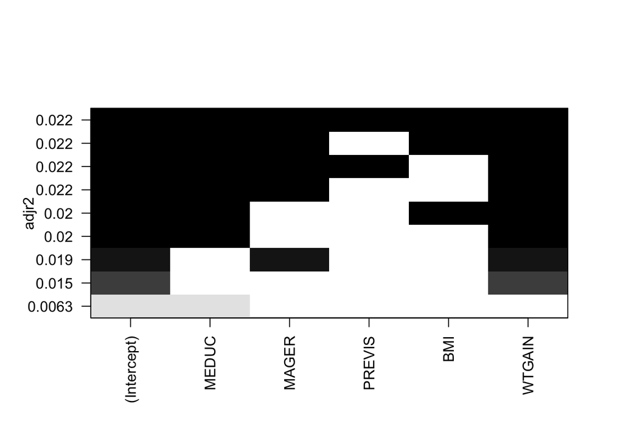

```r
#library(leaps)
comps <- leaps::regsubsets(DBWT ~ MEDUC + MAGER + PREVIS + BMI + WTGAIN, data=data_4, nbest=2)
plot(comps,scale="adjr2") #AdjustedRsquare chosen model is: MEDUC + MAGER + PREVIS + BMI + WTGAIN
```

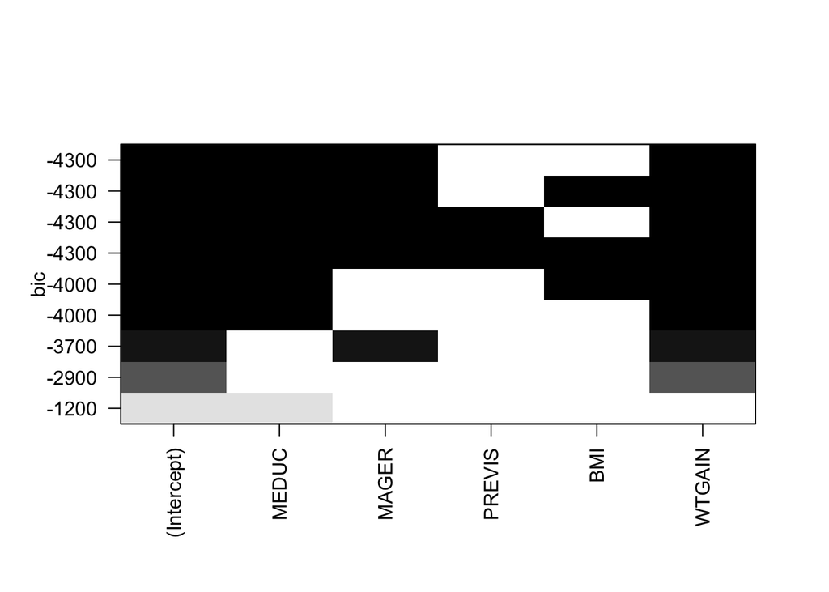

```r
plot(comps,scale="bic") #BIC chosen model is: MEDUC + MAGER + WTGAIN
```

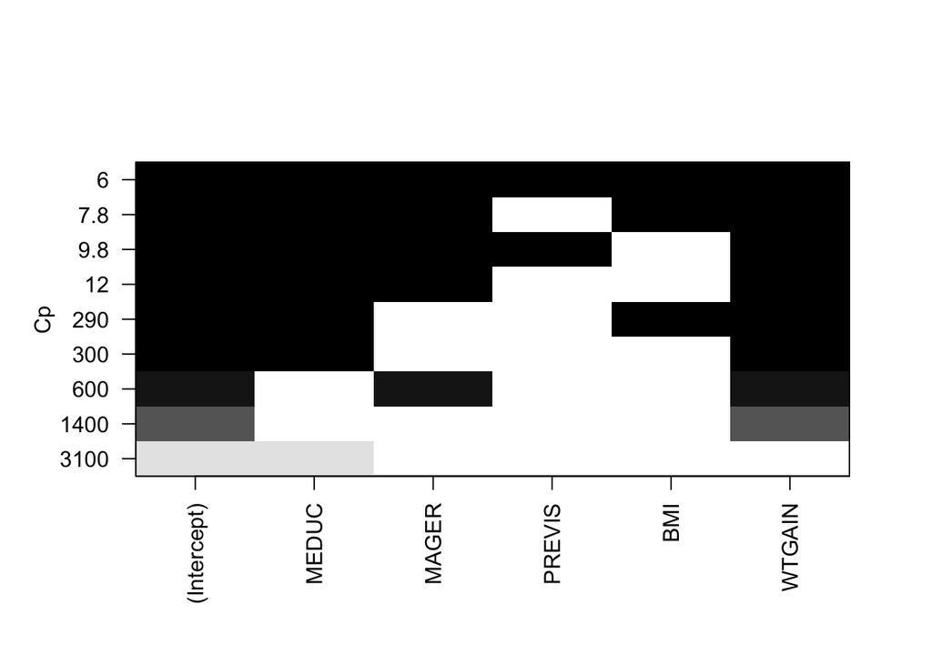

```r
plot(comps,scale="Cp") #Cp chosen model is: MEDUC + MAGER + PREVIS + BMI + WTGAIN
```

```r
lin2 <- glm(DBWT ~  MEDUC + MAGER + WTGAIN, data=data_4, family="gaussian")
names(summary(lin2))
```

```
##  [1] "call"           "terms"          "family"         "deviance"
##  [5] "aic"            "contrasts"      "df.residual"    "null.deviance"
##  [9] "df.null"        "iter"           "deviance.resid" "coefficients"
## [13] "aliased"        "dispersion"     "df"             "cov.unscaled"
## [17] "cov.scaled"
```

```r
fivenum(abs(summary(lin2)$deviance.resid))
```

```
##      163084       20003       92158      197600      104597
##    0.011782  151.726207  328.196949  585.926805 4670.277895
```

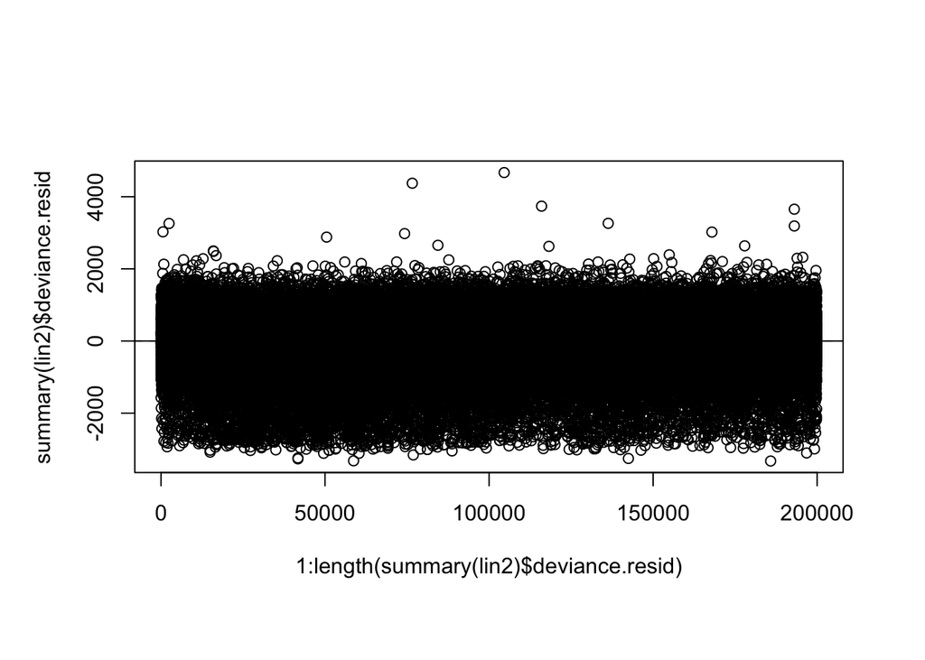

```r
plot(1:length(summary(lin2)$deviance.resid),summary(lin2)$deviance.resid)
abline(h=-2, lty=2)
abline(h=0)
abline(h=2, lty=2)
```

```r
#compare models
modelr::rmse(lin, data=data_4) #RMSE=585.5671
```

```
## [1] 585.5671
```

```r
rsq::rsq(lin,adj=FALSE) #R-squared=0.02164068
```

```
## [1] 0.02164068
```

```r
rsq::rsq(lin,adj=TRUE) #adjusted R-squared=0.02161621
```

```
## [1] 0.02161621
```

```r
summary(lin) #AIC: 3115141
```

```
##
## Call:
## glm(formula = DBWT ~ MEDUC + MAGER + PREVIS + BMI + WTGAIN, family = "gaussian",
##     data = data_4)
##
## Deviance Residuals:
##     Min       1Q   Median       3Q      Max
## -3346.6   -291.6     41.5    359.4   4670.9
##
## Coefficients:
##               Estimate Std. Error t value Pr(>|t|)
## (Intercept) 2940.87043    7.29494 403.138   <2e-16 ***
## MEDUC         20.99586    0.85540  24.545   <2e-16 ***
## MAGER          4.11759    0.24571  16.758   <2e-16 ***
## PREVIS        -0.15633    0.08040  -1.944   0.0518 .
## BMI            0.27686    0.11473   2.413   0.0158 *
## WTGAIN         3.66905    0.07086  51.778   <2e-16 ***
## ---
## Signif. codes:  0 '***' 0.001 '**' 0.01 '*' 0.05 '.' 0.1 ' ' 1
##
## (Dispersion parameter for gaussian family taken to be 342899.1)
##
##     Null deviance: 7.0061e+10  on 199904  degrees of freedom
## Residual deviance: 6.8545e+10  on 199899  degrees of freedom
## AIC: 3115141
##
## Number of Fisher Scoring iterations: 2
```

```r
modelr::rmse(lin2, data=data_4) #RMSE=585.5811
```

```
## [1] 585.5811
```

```r
rsq::rsq(lin2,adj=FALSE) #R-squared=0.02159378
```

```
## [1] 0.02159378
```

```r
rsq::rsq(lin2,adj=TRUE) #adjusted R-squared=0.02157909
```

```
## [1] 0.02157909
```

```r
summary(lin2) #AIC: 3115147
```

```
##
## Call:
## glm(formula = DBWT ~ MEDUC + MAGER + WTGAIN, family = "gaussian",
##     data = data_4)
##
## Deviance Residuals:
##     Min       1Q   Median       3Q      Max
## -3327.4   -291.7     41.3    359.4   4670.3
##
## Coefficients:
##              Estimate Std. Error t value Pr(>|t|)
## (Intercept) 2.945e+03  6.808e+00  432.63   <2e-16 ***
## MEDUC       2.070e+01  8.496e-01   24.37   <2e-16 ***
## MAGER       4.158e+00  2.448e-01   16.98   <2e-16 ***
## WTGAIN      3.708e+00  6.861e-02   54.04   <2e-16 ***
## ---
## Signif. codes:  0 '***' 0.001 '**' 0.01 '*' 0.05 '.' 0.1 ' ' 1
##
## (Dispersion parameter for gaussian family taken to be 342912.1)
##
##     Null deviance: 7.0061e+10  on 199904  degrees of freedom
## Residual deviance: 6.8548e+10  on 199901  degrees of freedom
## AIC: 3115147
##
## Number of Fisher Scoring iterations: 2
```

**#4. Conclusion** *VIF threshold of 10 is not violated, so I will not remove any predictors based on multicollinearity. There is no missing values. AIC chosen model is MEDUC + MAGER + PREVIS + BMI + WTGAIN. Automatic selection chosen model agree with AIC model except for BIC chosen model is MEDUC + MAGER + WTGAIN. When comparing the two models, although BIC chosen model had a slightly higher RMSE and lower R-squared value, the differences of these values are minimal, and the AIC only increased for 6, BIC model has 2 less predictors compared with AIC model. Therefore, I will chose the BIC chosen model with MEDUC + MAGER + WTGAIN. This model has RMSE=585.58 AIC=3115147 and adjusted R-squared=0.022, it is a poor fit model. Because we would prefer to have a high R-square and low RMSE, and low AIC. An interpretation of the model is: holding the other parameters constant: “as MEDUC (Mother’s Education)increases by 1 unit, the baby birth weight is estimated to increase by 20.7g, as MAGER (Mother’s Single Years of Age) increases by 1 unit, the baby birth weight is estimated to increase by 4.158g, as WTGAIN (Weight Gain) increases by 1 unit, the baby birth weight is estimated to increase by 3.708g.”*